# Simple NN with SoftMax

### Implementing Neural Network for classification problem using SoftMax function

#### The scripts relay on tutorial here: http://cs231n.github.io/neural-networks-case-study/#grad

#### In the implementation a toy data is generated

```python
import numpy as np
import matplotlib.pyplot as plt

%matplotlib inline
plt.rcParams['figure.figsize'] = (5.0, 4.0) # set default size of plots
plt.rcParams['image.interpolation'] = 'nearest'
plt.rcParams['image.cmap'] = 'gray'
```

```python
N = 100 # Number of data points per single class
D = 2   # Dimensionality of the data
K = 3   # Number of classes
```

```python
X = np.zeros( (N * K, D) )          # shape (300, 2)
y = np.zeros( (N*K), dtype='uint8' )  # shape (300, ) - a kind of (single) row vector

# Generate toy data set
# loop for each class...`
for j in range(K):
  ix = range(N*j,N*(j+1))
  r = np.linspace(0.0,1,N) # radius
  t = np.linspace(j*4,(j+1)*4,N) + np.random.randn(N)*0.2 # theta
  X[ix] = np.c_[r*np.sin(t), r*np.cos(t)]
  y[ix] = j
```

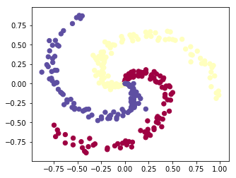

```python
# lets visualize the data:
plt.scatter(X[:, 0], X[:, 1], c=y, s=40, cmap=plt.cm.Spectral)
plt.show()
```

The data is alreadu within a range -1,1 so there is no need for features normalization (zero meean, unit standard deviation)

```python
# initialize parameters randomly
# D- number of dimensions, K - number of classes
W = 0.01 * np.random.randn(D,K)
b = np.zeros((1,K))

# Dimensions: X = [300,2], W = [2,3], b = [1,3]
```

```python
X[1:3]
```

```
array([[-0.00055839,  0.01008556],
       [-0.00544103,  0.01945551]])
```

```python
W[1:3]
```

```
array([[ 0.01632177,  0.00508961,  0.004371  ]])
```

```python
# Compute scores for linear classifier
scores = np.dot(X,W) + b
# scores = [300, 3] - number of data points and number of classes
```

```python
#Number of examples
num_of_examples = X.shape[0]
```

```python
# implementation source: https://gist.github.com/stober/1946926
# some theory source: https://eli.thegreenplace.net/2016/the-softmax-function-and-its-derivative/
def softmax(x):
    e_x = np.exp(x - np.max(x))
    out = e_x / e_x.sum()
    return out
```

```python
scores[1:3]
```

```
array([[  1.65367519e-04,   5.58346942e-05,   4.61196123e-05],
       [  3.24887974e-04,   1.42899652e-04,   1.04874915e-04]])
```

```python
probs = np.zeros((num_of_examples,K))
for t in range(num_of_examples):
    probs[t]=softmax(scores[t])
```

```python
# For each data point get a correct probability related to the data point class it belong to
corect_logprobs = -np.log(probs[range(num_of_examples),y])
```

```python
corect_logprobs[1:3]
```

```
array([ 1.09853603,  1.09847829])
```

```python
reg = 0.01
# compute the loss: average cross-entropy loss and regularization
data_loss = np.sum(corect_logprobs)/num_of_examples
reg_loss = 0.5*reg*np.sum(W*W)
loss = data_loss + reg_loss
```

```python
# Get a gradient related to each probabililty. The gradient is used to update weights
dscores = probs
dscores[range(num_of_examples),y] -= 1
dscores /= num_of_examples
```

```python
dscores.shape
```

```
(300, 3)
```

```python
dscores[1:4]
```

```
array([[-0.00222214,  0.00111107,  0.00111106],
       [-0.00222207,  0.00111106,  0.00111102],
       [-0.00222196,  0.001111  ,  0.00111097]])
```

```python
# X.T = [2, 300], dscores = [300,3]
dW = np.dot(X.T, dscores)

# axis=0 along the columns
# clarify this following operation
db = np.sum(dscores, axis=0, keepdims=True)  # [1,3]
dW += reg*W # don't forget the regularization gradient
```

```python
step_size = 0.01
# perform a parameter update
W += -step_size * dW
b += -step_size * db
```

```python
#Train a Linear Classifier

# initialize parameters randomly
W = 0.01 * np.random.randn(D,K)
b = np.zeros((1,K))

# some hyperparameters
step_size = 1e-0
reg = 1e-3 # regularization strength
epochs = 2000

# gradient descent loop
num_of_examples = X.shape[0]  # 300 = 100 X 3 =>  100 number of data points per class x 3 number of classes
for i in range(epochs):

    # evaluate class scores
    scores = np.dot(X, W) + b

    # compute the class probabilities
    probs = np.zeros((num_of_examples,K))
    for t in range(num_of_examples):
        probs[t]=softmax(scores[t])

    # compute the loss: average cross-entropy loss and regularization
    corect_logprobs = -np.log(probs[range(num_of_examples),y])
    data_loss = np.sum(corect_logprobs)/num_of_examples
    reg_loss = 0.5*reg*np.sum(W*W)
    loss = data_loss + reg_loss
    if i % 200 == 0:
        print("iteration {0}: loss {1}".format(i,loss))
        #print("iteration %d: loss %f" % (i, loss)
    if i == epochs-1:
        print("Final iteration {0}: loss {1}".format(i,loss))

    # compute the gradient on scores
    dscores = probs
    dscores[range(num_of_examples),y] -= 1
    dscores /= num_of_examples

    # backpropate the gradient to the parameters (W,b)
    dW = np.dot(X.T, dscores)
    db = np.sum(dscores, axis=0, keepdims=True)

    dW += reg*W # regularization gradient

    # perform a parameter update
    W += -step_size * dW
    b += -step_size * db
```

```
iteration 0: loss 1.0976798172998232
iteration 200: loss 0.7637352370248213
iteration 400: loss 0.7636090958564957
iteration 600: loss 0.7636086589630264
iteration 800: loss 0.7636086353787834
iteration 1000: loss 0.763608620488899
iteration 1200: loss 0.7636086105130354
iteration 1400: loss 0.7636086038273628
iteration 1600: loss 0.7636085993467194
iteration 1800: loss 0.7636085963438554
Final iteration 1999: loss 0.7636085943395693
```

```python
W
```

```
array([[ 1.15171571,  1.09010155, -2.24008019],
       [-2.64605326,  3.03785633, -0.3964419 ]])
```

```python
# "save" training weights
W_after_training = W
b_after_training = b
```

```python
# Training accurasy calculation
# Calcualte scores using trained weights and bias
AfterTrainScores = np.dot(X,W_after_training) + b_after_training

# Returns the indices of the maximum values along an axis.
predicted_class = np.argmax(AfterTrainScores, axis=1)

print("Accuracy based on training examples: {0}".format(np.mean( predicted_class == y)))
```

```
Accuracy based on training examples: 0.52
```

```
(-1.8903115432866946, 1.8696884567133087)
```

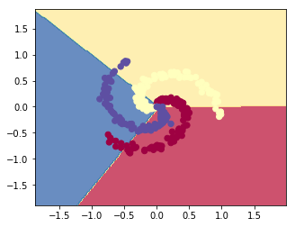

```python
# plot the resulting classifier
h = 0.02
x_min, x_max = X[:, 0].min() - 1, X[:, 0].max() + 1
y_min, y_max = X[:, 1].min() - 1, X[:, 1].max() + 1
xx, yy = np.meshgrid(np.arange(x_min, x_max, h),
                     np.arange(y_min, y_max, h))
Z = np.dot(np.c_[xx.ravel(), yy.ravel()], W) + b
Z = np.argmax(Z, axis=1)
Z = Z.reshape(xx.shape)
fig = plt.figure()
plt.contourf(xx, yy, Z, cmap=plt.cm.Spectral, alpha=0.8)
plt.scatter(X[:, 0], X[:, 1], c=y, s=40, cmap=plt.cm.Spectral)
plt.xlim(xx.min(), xx.max())
plt.ylim(yy.min(), yy.max())
#fig.savefig('spiral_linear.png')
```

#### Now the same training data byt NN with two hidden layers

```python
# initialize parameters randomly
h = 100 # size of hidden layer
W = 0.01 * np.random.randn(D,h)  # [2, 100]
b = np.zeros((1,h))              # [1, 100]
W2 = 0.01 * np.random.randn(h,K) # [100, 3]
b2 = np.zeros((1,K))             # [1, 3]
```

```python
# Forward pass

# input to activation function
hidden_layer_input = np.dot(X, W) + b  # [300,2] x [2, 100] = [300, 100] + [1, 100] = [300, 100]
# ReLu activation functio
hidden_layer = np.maximum(0, hidden_layer_input) # [300, 100]
# calculate logits
scores = np.dot(hidden_layer, W2) + b2           # [300,100] x [100,3] = [300, 3] + [1,3] = [300,3]
```

```python
# Backpropagation

# First calculate output values probs
probs = np.zeros((num_of_examples,K))
for t in range(num_of_examples):
    probs[t]=softmax(scores[t])

# Get a gradient related to each probabililty. The gradient is used to update weights of the second layer
dscores = probs                          # [300, 3] - we correct values of all weights that is why "3" is here
dscores[range(num_of_examples),y] -= 1   # [300, 3] - we also do the update of weights for all data points simultanosly
dscores /= num_of_examples               # [300, 3] - that is why "300" is here (300 training points in total)
```

```python
# backpropate the gradient to the parameters

# first backprop into parameters W2 and b2

# hidden_layer = [300,100]
# hidden layer' = [100,300] => [100,300] * [300,3] = [100,3]
dW2 = np.dot(hidden_layer.T, dscores)         # update for all of the weights between first hidden and second hidden layer
db2 = np.sum(dscores, axis=0, keepdims=True)  # = [1, 3]
```

```python
# continoue backpropagation to the first hidden layer
# push the gradient from the output (dscore) through the second layer weights to get is "at the ouput" of the first h layer

# dscore = [300,3], second hidden layer wieghts = [100,3]
dhidden = np.dot( dscores, W2.T)  # [300,3] x [3, 100] = [300,100]
```

```python
dhiddne_tmp = dhidden
```

```python
# Output of first hidden layer for a single example
# dhiddne_tmp[1]
```

Now we have the gradient on the outputs of the hidden layer. Next, we have to backpropagate the ReLU non-linearity. This turns out to be easy because ReLU during the backward pass is effectively a switch. Since r=max(0,x), we have that drdx=1(x>0). Combined with the chain rule, we see that the ReLU unit lets the gradient pass through unchanged if its input was greater than 0, but kills it if its input was less than zero during the forward pass. Hence, we can backpropagate the ReLU in place simply with:

```python
# Calculate gradient of the first hidden layer (using the propagated gradient "to the output of the first hidden layer")
dhidden[hidden_layer <= 0] = 0   # [300, 100]
```

```python
# dhidden[1]
```

And now we finally continue to the first layer weights and biases:

```python
# finally into W,b
dW = np.dot(X.T, dhidden)
# axis=0 -> along the columns
# clarify that step
db = np.sum(dhidden, axis=0, keepdims=True)
```

#### The full code of NN with two hidden layers

```python
# initialize parameters randomly
h = 100 # size of hidden layer
W = 0.01 * np.random.randn(D,h)
b = np.zeros((1,h))
W2 = 0.01 * np.random.randn(h,K)
b2 = np.zeros((1,K))

# some hyperparameters
step_size = 1e-0
#step_size = 1e-1
reg = 1e-3 # regularization strength
epochs = 2000

# gradient descent loop
num_examples = X.shape[0]
for i in range(epochs):
    # evaluate class scores, [N x K]
    hidden_layer = np.maximum(0, np.dot(X, W) + b) # note, ReLU activation
    scores = np.dot(hidden_layer, W2) + b2

    # compute the class probabilities
    probs = np.zeros((num_of_examples,K))
    for t in range(num_of_examples):
        probs[t]=softmax(scores[t])

    # compute the loss: average cross-entropy loss and regularization
    corect_logprobs = -np.log(probs[range(num_examples),y])
    data_loss = np.sum(corect_logprobs)/num_examples
    reg_loss = 0.5*reg*np.sum(W*W) + 0.5*reg*np.sum(W2*W2)
    loss = data_loss + reg_loss
    if i % 200 == 0:
        print("iteration {0}: loss {1},   reg_loss {2}".format(i,loss, reg_loss))
        #print("iteration %d: loss %f" % (i, loss)
    if i == epochs-1:
        print("Final iteration {0}: loss {1},   reg_loss {2}".format(i,loss, reg_loss))

    # compute the gradient on scores
    dscores = probs
    dscores[range(num_examples),y] -= 1
    dscores /= num_examples

    # backpropate the gradient to the parameters
    # first backprop into parameters W2 and b2
    dW2 = np.dot(hidden_layer.T, dscores)
    db2 = np.sum(dscores, axis=0, keepdims=True)
    # next backprop into hidden layer
    dhidden = np.dot(dscores, W2.T)
    # backprop the ReLU non-linearity
    dhidden[hidden_layer <= 0] = 0
    # finally into W,b
    dW = np.dot(X.T, dhidden)
    db = np.sum(dhidden, axis=0, keepdims=True)

    # add regularization gradient contribution
    dW2 += reg * W2
    dW += reg * W

    # perform a parameter update
    W += -step_size * dW
    b += -step_size * db
    W2 += -step_size * dW2
    b2 += -step_size * db2
```

```
iteration 0: loss 1.098690464851208,   reg_loss 2.80000229530253e-05
iteration 200: loss 0.6958477468627928,   reg_loss 0.014303881056115953
iteration 400: loss 0.37571227163081866,   reg_loss 0.05545584403442032
iteration 600: loss 0.2957156939524347,   reg_loss 0.08698678726324385
iteration 800: loss 0.3048821385334892,   reg_loss 0.10230130965611325
iteration 1000: loss 0.4094408501527054,   reg_loss 0.10988928811412081
iteration 1200: loss 0.27344819192562153,   reg_loss 0.11449270869028222
iteration 1400: loss 0.27908267702830386,   reg_loss 0.11764647384491644
iteration 1600: loss 0.2685237604880223,   reg_loss 0.11999650509266488
iteration 1800: loss 0.2683140207946442,   reg_loss 0.12223327720082443
Final iteration 1999: loss 0.2619591791368,   reg_loss 0.12471494987295795
```

```python
# Training accurasy calculation
# Calcualte scores using trained weights and bias
hidden_layer = np.maximum(0, np.dot(X, W) + b)
AfterTrainScores = np.dot(hidden_layer, W2) + b2

# Returns the indices of the maximum values along an axis.
predicted_class = np.argmax(AfterTrainScores, axis=1)

print("Accuracy based on training examples: {0}".format(np.mean( predicted_class == y)))
```

```
Accuracy based on training examples: 0.9533333333333334
```

```
(-1.8903115432866946, 1.8696884567133087)
```

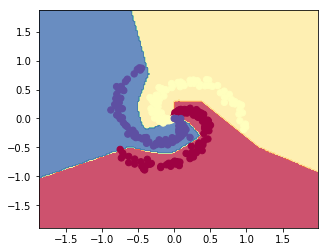

```python
# plot the resulting classifier
h = 0.02
x_min, x_max = X[:, 0].min() - 1, X[:, 0].max() + 1
y_min, y_max = X[:, 1].min() - 1, X[:, 1].max() + 1
xx, yy = np.meshgrid(np.arange(x_min, x_max, h),
                     np.arange(y_min, y_max, h))
Z = np.dot(np.maximum(0, np.dot(np.c_[xx.ravel(), yy.ravel()], W) + b), W2) + b2
Z = np.argmax(Z, axis=1)
Z = Z.reshape(xx.shape)
fig = plt.figure()
plt.contourf(xx, yy, Z, cmap=plt.cm.Spectral, alpha=0.8)
plt.scatter(X[:, 0], X[:, 1], c=y, s=40, cmap=plt.cm.Spectral)
plt.xlim(xx.min(), xx.max())
plt.ylim(yy.min(), yy.max())
#fig.savefig('spiral_net.png')
```

Neural network with two hidden layer:

```python
sigmoid_function = lambda x: 1 / ( 1 + np.exp(-x))
sigmoid_derivative = lambda sig: sig * (1-sig)
```

```python
tmp_input = [1, 2, 3, 4]
print(type(tmp_input))
print(tmp_input)
```

```
<class 'list'>
[1, 2, 3, 4]
```

```python
tmp_input2 = np.array(tmp_input)
print(type(tmp_input2))
print(tmp_input2)
```

```
<class 'numpy.ndarray'>
[1 2 3 4]
```

```python
sigmoid_function(tmp_input2)
```

```
array([ 0.73105858,  0.88079708,  0.95257413,  0.98201379])
```

```python
sigmoid_derivative(tmp_input2)
```

```
array([  0,  -2,  -6, -12])
```

```python
tmp_input3 = list(tmp_input2)
print(type(tmp_input3))
print(tmp_input3)
```

```
<class 'list'>
[1, 2, 3, 4]
```

```python
# initialize parameters randomly
h = 5 # size of hidden layer
W = 0.01 * np.random.randn(D,h)  # [2, 5]
b = np.zeros((1,h))              # [1, 5]
W2 = 0.01 * np.random.randn(h,K) # [5, 3]
b2 = np.zeros((1,K))             # [1, 3]
```

```python
# Forward pass

# input to activation function
hidden_layer_input = np.dot(X, W) + b  # [300,2] x [2, 5] = [300, 5] + [1, 5] = [300, 5]
# ReLu activation functio
hidden_layer = sigmoid_function(hidden_layer_input) # [300, 5]
# calculate logits
scores = np.dot(hidden_layer, W2) + b2           # [300,5] x [5,3] = [300, 3] + [1,3] = [300,3]
```

```python
# Backpropagation

# First calculate output values probs
probs = np.zeros((num_of_examples,K))
for t in range(num_of_examples):
    probs[t]=softmax(scores[t])

# Get a gradient related to each probabililty. The gradient is used to update weights of the second layer
dscores = probs                          # [300, 3] - we correct values of all weights that is why "3" is here
dscores[range(num_of_examples),y] -= 1   # [300, 3] - we also do the update of weights for all data points simultanosly
dscores /= num_of_examples               # [300, 3] - that is why "300" is here (300 training points in total)
```

```python
# backpropate the gradient to the parameters

# first backprop into parameters W2 and b2

# hidden_layer = [300,5]
# hidden layer' = [5,300] => [5,300] * [300,3] = [5,3]
dW2 = np.dot(hidden_layer.T, dscores)         # update for all of the weights between first hidden and second hidden layer
db2 = np.sum(dscores, axis=0, keepdims=True)  # = [1, 3]
```

```python
# continoue backpropagation to the first hidden layer
# push the gradient from the output (dscore) through the second layer weights to get is "at the ouput" of the first h layer

# dscore = [300,3], second hidden layer wieghts = [100,3]
dhidden_at_the_output_of_1st_hidden_layer = np.dot( dscores, W2.T)  # [300,3] x [3, 5] = [300,5]
```

```python
dhidden = sigmoid_derivative( dhidden_at_the_output_of_1st_hidden_layer )
```

```python
# finally into W,b
dW = np.dot(X.T, dhidden)
# axis=0 -> along the columns
# clarify that step
db = np.sum(dhidden, axis=0, keepdims=True)
```

```python
# initialize parameters randomly
h = 200 # size of hidden layer
W = 0.01 * np.random.randn(D,h)
b = np.zeros((1,h))
W2 = 0.01 * np.random.randn(h,K)
b2 = np.zeros((1,K))

# some hyperparameters
#step_size = 1e-0
step_size = 0.8
reg = 1e-3 # regularization strength
#reg = 1e-6 # regularization strength
epochs = 8000

# gradient descent loop
num_examples = X.shape[0]
for i in range(epochs):
    # evaluate class scores, [N x K]
    hidden_layer = np.maximum(0, np.dot(X, W) + b) # note, ReLU activation
    scores = np.dot(hidden_layer, W2) + b2

    # compute the class probabilities
    probs = np.zeros((num_of_examples,K))
    for t in range(num_of_examples):
        probs[t]=softmax(scores[t])

    # compute the loss: average cross-entropy loss and regularization
    corect_logprobs = -np.log(probs[range(num_examples),y])
    data_loss = np.sum(corect_logprobs)/num_examples
    reg_loss = 0.5*reg*np.sum(W*W) + 0.5*reg*np.sum(W2*W2)
    loss = data_loss + reg_loss
    if i % 1000 == 0:
        print("iteration {0}: loss {1},   reg_loss {2}".format(i,loss, reg_loss))
        #print("iteration %d: loss %f" % (i, loss)
    if i == epochs-1:
        print("Final iteration {0}: loss {1},   reg_loss {2}".format(i,loss, reg_loss))

    # compute the gradient on scores
    dscores = probs
    dscores[range(num_examples),y] -= 1
    dscores /= num_examples

    # backpropate the gradient to the parameters
    # first backprop into parameters W2 and b2
    dW2 = np.dot(hidden_layer.T, dscores)
    db2 = np.sum(dscores, axis=0, keepdims=True)
    # next backprop into hidden layer
    dhidden_at_the_output_of_1st_hidden_layer = np.dot(dscores, W2.T)
    # backprop the sigmoid non-linearity
    dhidden = sigmoid_derivative( dhidden_at_the_output_of_1st_hidden_layer )
    # finally into W,b
    dW = np.dot(X.T, dhidden)
    db = np.sum(dhidden, axis=0, keepdims=True)

    # add regularization gradient contribution
    dW2 += reg * W2
    dW += reg * W

    # perform a parameter update
    W += -step_size * dW
    b += -step_size * db
    W2 += -step_size * dW2
    b2 += -step_size * db2
```

```
iteration 0: loss 1.098718056902445,   reg_loss 4.9492785362643035e-05
iteration 1000: loss 0.6619490752918963,   reg_loss 0.03622706807646941
iteration 2000: loss 0.7140795007984259,   reg_loss 0.04507663633061142
iteration 3000: loss 0.6976710852031086,   reg_loss 0.03342384417750128
iteration 4000: loss 0.6764805054662205,   reg_loss 0.029966837132342817
iteration 5000: loss 0.7588320277183105,   reg_loss 0.029154310033757885
iteration 6000: loss 0.6989414651080162,   reg_loss 0.028434116984523538
iteration 7000: loss 0.706416232496816,   reg_loss 0.025691715509595252
Final iteration 7999: loss 0.73462895465423,   reg_loss 0.023131074992502446
```

```python
# Training accurasy calculation
# Calcualte scores using trained weights and bias
hidden_layer = np.maximum(0, np.dot(X, W) + b)
AfterTrainScores = np.dot(hidden_layer, W2) + b2

# Returns the indices of the maximum values along an axis.
predicted_class = np.argmax(AfterTrainScores, axis=1)

print("Accuracy based on training examples: {0}".format(np.mean( predicted_class == y)))
```

```
Accuracy based on training examples: 0.5433333333333333
```

```
(-1.8903115432866946, 1.8696884567133087)
```

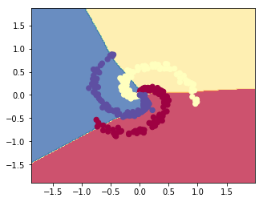

```python
# plot the resulting classifier
h = 0.02
x_min, x_max = X[:, 0].min() - 1, X[:, 0].max() + 1
y_min, y_max = X[:, 1].min() - 1, X[:, 1].max() + 1
xx, yy = np.meshgrid(np.arange(x_min, x_max, h),
                     np.arange(y_min, y_max, h))
Z = np.dot(np.maximum(0, np.dot(np.c_[xx.ravel(), yy.ravel()], W) + b), W2) + b2
Z = np.argmax(Z, axis=1)
Z = Z.reshape(xx.shape)
fig = plt.figure()
plt.contourf(xx, yy, Z, cmap=plt.cm.Spectral, alpha=0.8)
plt.scatter(X[:, 0], X[:, 1], c=y, s=40, cmap=plt.cm.Spectral)
plt.xlim(xx.min(), xx.max())
plt.ylim(yy.min(), yy.max())
#fig.savefig('spiral_net.png')
```